# Developing an AI application

Going forward, AI algorithms will be incorporated into more and more everyday applications. For example, you might want to include an image classifier in a smart phone app. To do this, you'd use a deep learning model trained on hundreds of thousands of images as part of the overall application architecture. A large part of software development in the future will be using these types of models as common parts of applications.

In this project, you'll train an image classifier to recognize different species of flowers. You can imagine using something like this in a phone app that tells you the name of the flower your camera is looking at. In practice you'd train this classifier, then export it for use in your application. We'll be using [this dataset](http://www.robots.ox.ac.uk/~vgg/data/flowers/102/index.html) of 102 flower categories, you can see a few examples below.

[figure not shown]

The project is broken down into multiple steps:

- Load and preprocess the image dataset
- Train the image classifier on your dataset
- Use the trained classifier to predict image content

We'll lead you through each part which you'll implement in Python.

When you've completed this project, you'll have an application that can be trained on any set of labeled images. Here your network will be learning about flowers and end up as a command line application. But, what you do with your new skills depends on your imagination and effort in building a dataset. For example, imagine an app where you take a picture of a car, it tells you what the make and model is, then looks up information about it. Go build your own dataset and make something new.

First up is importing the packages you'll need. It's good practice to keep all the imports at the beginning of your code. As you work through this notebook and find you need to import a package, make sure to add the import up here.

```python
# Imports here
%matplotlib inline
%config InlineBackend.figure_format = 'retina'

import argparse
import copy
import time
from collections import OrderedDict
from datetime import datetime
from pathlib import Path
import matplotlib.pyplot as plt
from PIL import Image
import numpy as np

import torch
import torch.nn as nn
import torch.nn.parallel
import torch.optim
import torch.utils.data
import torch.utils.data.distributed
import torchvision.datasets as datasets
import torchvision.models as models
import torchvision.transforms as transforms
from torch import optim
from torch.optim import lr_scheduler
from torch.autograd import Variable
import seaborn as sns
```

## Load the data

Here you'll use `torchvision` to load the data ([documentation](http://pytorch.org/docs/0.3.0/torchvision/index.html)). The data should be included alongside this notebook, otherwise you can [download it here](https://s3.amazonaws.com/content.udacity-data.com/nd089/flower_data.tar.gz). The dataset is split into three parts, training, validation, and testing. For the training, you'll want to apply transformations such as random scaling, cropping, and flipping. This will help the network generalize leading to better performance. You'll also need to make sure the input data is resized to 224x224 pixels as required by the pre-trained networks.

The validation and testing sets are used to measure the model's performance on data it hasn't seen yet. For this you don't want any scaling or rotation transformations, but you'll need to resize then crop the images to the appropriate size.

The pre-trained networks you'll use were trained on the ImageNet dataset where each color channel was normalized separately. For all three sets you'll need to normalize the means and standard deviations of the images to what the network expects. For the means, it's `[0.485, 0.456, 0.406]` and for the standard deviations `[0.229, 0.224, 0.225]`, calculated from the ImageNet images. These values will shift each color channel to be centered at 0 and range from -1 to 1.

```python
data_dir = 'flowers'
train_dir = data_dir + '/train'
valid_dir = data_dir + '/valid'
test_dir = data_dir + '/test'

# for easy iteration later
dirs_dict = {'train': train_dir, 'valid': valid_dir, 'test': test_dir}

# variable for various iterations later
states = ['train', 'valid', 'test']
```

```python
# TODO: Define your transforms for the training, validation, and testing sets

batch_size = 32

# image normalization parameters, predefined
normalize = transforms.Normalize([0.485, 0.456, 0.406],
                                 [0.229, 0.224, 0.225])

# transforms for valid and test data, use same parameters
valid_test_transforms = [
    transforms.Resize(256),
    transforms.CenterCrop(224),
    transforms.ToTensor(),
    normalize]

data_transforms = {
    'train':  # vector manipulation for generalized learning
    transforms.Compose([
        transforms.RandomResizedCrop(224),
        transforms.RandomRotation(30),
        transforms.RandomHorizontalFlip(),
        transforms.RandomVerticalFlip(),
        transforms.ToTensor(),
        normalize
    ]),
    'valid':
        transforms.Compose(valid_test_transforms),
        'test':
        transforms.Compose(valid_test_transforms)
}

image_sets = {
    i_set: datasets.ImageFolder(
        dirs_dict[i_set], transform=data_transforms[i_set])
    for i_set in states
}

dataloaders = {
    'train': torch.utils.data.DataLoader(
        image_sets['train'], batch_size=batch_size, shuffle=True),
    'valid': torch.utils.data.DataLoader(image_sets['valid'],       batch_size=batch_size),
    'test': torch.utils.data.DataLoader(image_sets['test'], batch_size=batch_size)
}
classes = image_sets['train'].classes
data_sizes = {x: len(image_sets[x]) for x in states}
```

### Label mapping

You'll also need to load in a mapping from category label to category name. You can find this in the file `cat_to_name.json`. It's a JSON object which you can read in with the [`json` module](https://docs.python.org/2/library/json.html). This will give you a dictionary mapping the integer encoded categories to the actual names of the flowers.

```python
import json

with open('cat_to_name.json', 'r') as f:
    label_dict = json.load(f)
```

# Building and training the classifier

Now that the data is ready, it's time to build and train the classifier. As usual, you should use one of the pretrained models from `torchvision.models` to get the image features. Build and train a new feed-forward classifier using those features.

We're going to leave this part up to you. If you want to talk through it with someone, chat with your fellow students! You can also ask questions on the forums or join the instructors in office hours.

Refer to [the rubric](https://review.udacity.com/#!/rubrics/1663/view) for guidance on successfully completing this section. Things you'll need to do:

- Load a [pre-trained network](http://pytorch.org/docs/master/torchvision/models.html) (If you need a starting point, the VGG networks work great and are straightforward to use)
- Define a new, untrained feed-forward network as a classifier, using ReLU activations and dropout
- Train the classifier layers using backpropagation using the pre-trained network to get the features
- Track the loss and accuracy on the validation set to determine the best hyperparameters

We've left a cell open for you below, but use as many as you need. Our advice is to break the problem up into smaller parts you can run separately. Check that each part is doing what you expect, then move on to the next. You'll likely find that as you work through each part, you'll need to go back and modify your previous code. This is totally normal!

When training make sure you're updating only the weights of the feed-forward network. You should be able to get the validation accuracy above 70% if you build everything right. Make sure to try different hyperparameters (learning rate, units in the classifier, epochs, etc) to find the best model. Save those hyperparameters to use as default values in the next part of the project.

```python
# TODO: Build and train your network
model = models.vgg11(pretrained=True)

for p in model.parameters():
    p.requires_grad = False

dropout = 0.30
hidden_units = 4096


classifier = nn.Sequential(
    OrderedDict([
        ('fc1', nn.Linear(
                model.classifier[0].in_features, hidden_units)),
        ('relu1,', nn.ReLU()),
        ('dropout', nn.Dropout(dropout)),
        ('fc2', nn.Linear(hidden_units, len(classes))),
        ('output', nn.LogSoftmax(dim=1)),
    ]))

model.classifier = classifier
```

```
Downloading: "https://download.pytorch.org/models/vgg11-bbd30ac9.pth" to /root/.torch/models/vgg11-bbd30ac9.pth
```

```python
def train(model, optimizer, criterion, scheduler, num_epochs, device):
    """
    trains a selected model using CNN
    Parameters:
        model - Model selected from list of available models
        optimizer - optimizer used during training
        criterion - loss function to optimize
        scheduler - learning rate scheduler
        num_epochs - number of epochs to train the model with (default: 5)
        device - gpu or cpu (default: cpu)
    Returns:
        The trained model
    """

    begin = time.time()  # global loop time

    top_acc = 0.
    top_model_weights = copy.deepcopy(model.state_dict())

    for e in range(num_epochs):
        epoch_start = time.time()  # epoch starting time
        print('=> running epoch {}/{}'.format(e + 1, num_epochs))

        for state in ['train', 'valid']:
            if state == 'train':
                scheduler.step()  # changes learning rate
                model.train()  # this puts the model into a training state
            else:
                model.eval()  # this puts the model into an evaluation state

            running_loss = 0.
            running_correct = 0

            for images, labels in dataloaders[state]:
                images = images.to(device)  # send to GPU or CPU
                labels = labels.to(device)  # send to GPU or CPU

                optimizer.zero_grad()

                with torch.set_grad_enabled(state == 'train'):
                    model = model.to(device)  # sends to GPU or CPU
                    output = model(images)
                    _, predicts = torch.max(output, 1)
                    loss = criterion(output, labels)

                    if state == 'train':
                        loss.backward()  # backpropogation
                        optimizer.step()

                running_loss += loss.item() * images.size(0)  # add to running loss

                # total of correct predictions
                running_correct += torch.sum(predicts == labels.data)

            e_loss = running_loss / data_sizes[state]  # epoch loss

            # epoch accuracy, double() used to change tensor data type
            e_acc = running_correct.double() / data_sizes[state]

            # print running loss and accuracy for train and validation sets
            print('=> {} loss: {:.4f} acc: {:.4f}'.format(state, e_loss, e_acc))

            if state == 'valid' and e_acc > top_acc:
                top_acc = e_acc  # sets the top accuracy if exceeds existing max

                # save model state at highest accuracy
                top_model_weights = copy.deepcopy(model.state_dict())

        epoch_time = time.time() - epoch_start  # total epoch run time
        print('=> epoch run time: {:.0f}m {:.0f}s '.format(
            epoch_time // 60, epoch_time % 60))
        print('* ' * 20)

    total_time = time.time() - begin  # total train run time
    print('=> completed in {:.0f}m {:.0f}s'.format(
        total_time // 60, total_time % 60))
    print('=> highest accuracy: {:.4f}'.format(top_acc))

    # load highest accuracy model and return it
    model.load_state_dict(top_model_weights)

    return model
```

```python
epochs = 20
learning_rate = 0.001

device = torch.device("cuda:0" if (
    torch.cuda.is_available()) else "cpu")

criterion = nn.NLLLoss()

optimizer = optim.Adam(model.classifier.parameters(),
                       lr=learning_rate)

scheduler = lr_scheduler.StepLR(optimizer, step_size=10, gamma=0.0125)

model_trained = train(model, optimizer, criterion,
                      scheduler, epochs, device)
```

```
=> running epoch 1/20
=> train loss: 3.2139 acc: 0.3428
=> valid loss: 1.1142 acc: 0.7029
=> epoch run time: 2m 13s
* * * * * * * * * * * * * * * * * * * *
=> running epoch 2/20
=> train loss: 1.7008 acc: 0.5578
=> valid loss: 0.8617 acc: 0.7751
=> epoch run time: 2m 4s
* * * * * * * * * * * * * * * * * * * *
=> running epoch 3/20
=> train loss: 1.5207 acc: 0.6029
=> valid loss: 0.8214 acc: 0.7714
=> epoch run time: 2m 4s
* * * * * * * * * * * * * * * * * * * *
=> running epoch 4/20
=> train loss: 1.4108 acc: 0.6210
=> valid loss: 0.7317 acc: 0.8154
=> epoch run time: 2m 4s
* * * * * * * * * * * * * * * * * * * *
=> running epoch 5/20
=> train loss: 1.3714 acc: 0.6404
=> valid loss: 0.7735 acc: 0.7995
=> epoch run time: 2m 4s
* * * * * * * * * * * * * * * * * * * *
=> running epoch 6/20
=> train loss: 1.3351 acc: 0.6548
=> valid loss: 0.5960 acc: 0.8472
=> epoch run time: 2m 4s
* * * * * * * * * * * * * * * * * * * *
=> running epoch 7/20
=> train loss: 1.2719 acc: 0.6644
=> valid loss: 0.6161 acc: 0.8374
=> epoch run time: 2m 4s
* * * * * * * * * * * * * * * * * * * *
=> running epoch 8/20
=> train loss: 1.2493 acc: 0.6757
=> valid loss: 0.6325 acc: 0.8399
=> epoch run time: 2m 4s
* * * * * * * * * * * * * * * * * * * *
```

[output cut: 47 more lines]

```
=> valid loss: 0.4951 acc: 0.8790
=> epoch run time: 2m 4s
* * * * * * * * * * * * * * * * * * * *
=> running epoch 19/20
=> train loss: 0.9324 acc: 0.7456
=> valid loss: 0.4923 acc: 0.8826
=> epoch run time: 2m 5s
* * * * * * * * * * * * * * * * * * * *
=> running epoch 20/20
=> train loss: 0.9046 acc: 0.7502
=> valid loss: 0.4896 acc: 0.8802
=> epoch run time: 2m 4s
* * * * * * * * * * * * * * * * * * * *
=> completed in 41m 30s
=> highest accuracy: 0.8826
```

## Testing your network

It's good practice to test your trained network on test data, images the network has never seen either in training or validation. This will give you a good estimate for the model's performance on completely new images. Run the test images through the network and measure the accuracy, the same way you did validation. You should be able to reach around 70% accuracy on the test set if the model has been trained well.

```python
# helper functions

def accuracy_calc(model, data, cuda=False):
    model.eval()
    model.to(device='cuda')

    with torch.no_grad():
        for index, (images, labels) in enumerate(dataloaders[data]):

            if cuda:
                images, labels = images.cuda(), labels.cuda()

            output = model.forward(images)  # predict

            _, predictions = output.max(
                dim=1)  # extract predictions and probabilities

            if index == 0:
                print(predictions)
                print(torch.exp(_))
            equals = predictions == labels.data  # boolean comparisons of correct preds

            if index == 0:
                print(equals)
            print(equals.float().mean())


def validation(model, testloader, criterion, device):
    accuracy = 0
    test_loss = 0
    for images, labels in iter(testloader):
        images, labels = images.to(device), labels.to(device)
        output = model.forward(images)
        test_loss += criterion(output, labels).item()
        ps = torch.exp(output)
        equality = (labels.data == ps.max(1)[1])
        accuracy += equality.type_as(torch.cuda.FloatTensor()).mean()

    return test_loss, accuracy
```

```python
# TODO: Do validation on the test set

accuracy_calc(model, 'test', True)
with torch.no_grad():
    model.eval()
    test_loss, accuracy = validation(
        model, dataloaders['test'], criterion, device='cuda')
    print("Test Loss: {:.4f} ".format(test_loss / len(dataloaders['test'])),
          "Test Accuracy: {:.4f}".format(accuracy / len(dataloaders['test'])))
```

```
tensor([  0,   0,  99,  90,   0,   1,   1,   1,   2,   2,   2,  43,
          2,   2,   2,   2,   3,   3,   3,   3,   4,   4,   4,   4,
          4,   4,  69,  98,   5,   5,   5,  98], device='cuda:0')
tensor([ 0.9996,  0.8935,  0.2260,  0.7897,  0.4412,  0.6573,  1.0000,
         0.9993,  0.9976,  1.0000,  1.0000,  0.5964,  0.9969,  0.9991,
         1.0000,  0.9997,  0.6650,  0.9792,  0.9832,  0.5165,  1.0000,
         1.0000,  0.9994,  0.9383,  0.9891,  1.0000,  0.6937,  0.2296,
         0.9216,  0.5940,  0.9878,  0.5473], device='cuda:0')
tensor([ 1,  1,  0,  0,  1,  1,  1,  1,  1,  1,  1,  0,  1,  1,
         1,  1,  1,  1,  1,  1,  1,  1,  1,  1,  1,  1,  0,  0,
         1,  1,  1,  0], dtype=torch.uint8, device='cuda:0')
tensor(0.8125, device='cuda:0')
tensor(0.8125, device='cuda:0')
tensor(0.8750, device='cuda:0')
tensor(0.8750, device='cuda:0')
tensor(0.7188, device='cuda:0')
tensor(0.9062, device='cuda:0')
tensor(0.6250, device='cuda:0')
tensor(0.8125, device='cuda:0')
tensor(0.9375, device='cuda:0')
tensor(0.9375, device='cuda:0')
tensor(0.8125, device='cuda:0')
tensor(1., device='cuda:0')
tensor(0.9688, device='cuda:0')
tensor(0.9375, device='cuda:0')
tensor(0.9375, device='cuda:0')
tensor(0.7812, device='cuda:0')
tensor(0.8750, device='cuda:0')
tensor(1., device='cuda:0')
tensor(0.9688, device='cuda:0')
tensor(0.9688, device='cuda:0')
tensor(0.7812, device='cuda:0')
tensor(0.7812, device='cuda:0')
tensor(0.8125, device='cuda:0')
tensor(0.8750, device='cuda:0')
tensor(0.9375, device='cuda:0')
tensor(0.6842, device='cuda:0')
Test Loss: 0.5453  Test Accuracy: 0.8629
```

## Save the checkpoint

Now that your network is trained, save the model so you can load it later for making predictions. You probably want to save other things such as the mapping of classes to indices which you get from one of the image datasets: `image_datasets['train'].class_to_idx`. You can attach this to the model as an attribute which makes inference easier later on.

`model.class_to_idx = image_datasets['train'].class_to_idx`

Remember that you'll want to completely rebuild the model later so you can use it for inference. Make sure to include any information you need in the checkpoint. If you want to load the model and keep training, you'll want to save the number of epochs as well as the optimizer state, `optimizer.state_dict`. You'll likely want to use this trained model in the next part of the project, so best to save it now.

```python
def save_checkpoint(model, epochs, save_dir, arch, learning_rate, optimizer, hidden_units):
    """
    saves the trained and tested module by saving a checkpoint file to an optional directory
    params:
        model - tested and trained CNN
        epochs - number of epochs used to train
        save_dir - directory to save the checkpoint file(default - current wd)
        arch - pass string value of architecture used for loading
    returns:
        none - use module to save checkpoint
    """

    model.class_to_idx = image_sets['train'].class_to_idx

    file_name = 'checkpoint-' + \
        str(datetime.now().strftime("%Y-%m-%d-%H:%M")) + \
        '.pth'  # dynamic time file naming
    model.cpu()  # make sure it saves locally
    saved_model = {
        'arch': arch,  # save model architecture
        'classifier': model.classifier,  # save classifier structure
        'class_to_idx': model.class_to_idx,  # save class to index mapping
        'epochs': epochs,  # save num of epochs
        'hidden_units': hidden_units,  # save num of hidden units
        'learning_rate': learning_rate,  # save learning rate used
        'optimizer_dict': optimizer.state_dict(),  # save optimizer state dictionary
        'state_dict': model.state_dict(),  # save model state dict
    }

    if len(save_dir) == 0:
        save_path = save_dir + file_name  # save in current directory if no path provided
    else:
        save_path = save_dir + '/' + file_name  # save in specified file directory

    torch.save(saved_model, save_path)  # save file

    if len(save_dir) == 0:
        print('=> model checkpoint saved in current working directory')
    else:
        print('=> model checkpoint saved at {}'.format(save_path))
```

```python
save_checkpoint(model_trained, epochs, '', 'vgg11', learning_rate, optimizer, hidden_units)
```

```
=> model checkpoint saved in current working directory
```

## Loading the checkpoint

At this point it's good to write a function that can load a checkpoint and rebuild the model. That way you can come back to this project and keep working on it without having to retrain the network.

```python
def load_model(checkpoint, device):
    '''
    loads model from checkpoint
    params:
        checkpoint - checkpoint of already trained CNN with custom classifier
        device - cuda or cpu
    returns:
        the loadeda model, loaded model's architecture, class to index mapping
    '''

    model_names = sorted(name for name in models.__dict__
                         if name.islower() and not name.startswith("__")
                         and callable(models.__dict__[name]) and name.startswith('vg'))

    if str(device) == "cpu":
        model_trained = torch.load(checkpoint, map_location=device)
    else:
        model_trained = torch.load(checkpoint)

    arch = model_trained['arch']
    class_to_idx = model_trained['class_to_idx']

    if arch in model_names:
        load_model = eval('models.' + arch + '(pretrained=True)')
    else:
        print('{} architecture not recognized. Supported arguments: {}'.format(
            arch, ', '.join(model_names)))
        sys.exit()

    for par in load_model.parameters():
        par.requires_grad = False

    load_model.classifier = model_trained['classifier']
    load_model.load_state_dict(model_trained['state_dict'])
    load_model.class_to_idx = model_trained['class_to_idx']

    return load_model, arch, class_to_idx
```

**NOTE TO REVIEWER: I DID NOT INCLUDE THE CHECKPOINT FILE IN MY UPLOAD (IT WAS VERY LARGE) SO THE BELOW CODE WILL NOT RUN**

```python
epochs = 30
learning_rate = 0.001

device = torch.device("cuda:0" if (
    torch.cuda.is_available()) else "cpu")

criterion = nn.NLLLoss()

optimizer = optim.Adam(model.classifier.parameters(),
                       lr=learning_rate)

model_loaded, loaded_arch, loaded_class_idx = load_model(
    'checkpoint-2018-08-26-17:47.pth', device)


accuracy_calc(model_loaded, 'test', True)
with torch.no_grad():
    model_loaded.eval()
    test_loss, accuracy = validation(
        model_loaded, dataloaders['test'], criterion, device=device)
    print("Test Loss: {:.4f} ".format(test_loss / len(dataloaders['test'])),
          "Test Accuracy: {:.4f}".format(accuracy / len(dataloaders['test'])))
```

```
tensor([  0,   0,  99,  90,   0,   1,   1,   1,   2,   2,   2,  43,
          2,   2,   2,   2,   3,   3,   3,   3,   4,   4,   4,   4,
          4,   4,  69,  98,   5,   5,   5,  98], device='cuda:0')
tensor([ 0.9996,  0.8935,  0.2260,  0.7897,  0.4412,  0.6573,  1.0000,
         0.9993,  0.9976,  1.0000,  1.0000,  0.5964,  0.9969,  0.9991,
         1.0000,  0.9997,  0.6650,  0.9792,  0.9832,  0.5165,  1.0000,
         1.0000,  0.9994,  0.9383,  0.9891,  1.0000,  0.6937,  0.2296,
         0.9216,  0.5940,  0.9878,  0.5473], device='cuda:0')
tensor([ 1,  1,  0,  0,  1,  1,  1,  1,  1,  1,  1,  0,  1,  1,
         1,  1,  1,  1,  1,  1,  1,  1,  1,  1,  1,  1,  0,  0,
         1,  1,  1,  0], dtype=torch.uint8, device='cuda:0')
tensor(0.8125, device='cuda:0')
tensor(0.8125, device='cuda:0')
tensor(0.8750, device='cuda:0')
tensor(0.8750, device='cuda:0')
tensor(0.7188, device='cuda:0')
tensor(0.9062, device='cuda:0')
tensor(0.6250, device='cuda:0')
tensor(0.8125, device='cuda:0')
tensor(0.9375, device='cuda:0')
tensor(0.9375, device='cuda:0')
tensor(0.8125, device='cuda:0')
tensor(1., device='cuda:0')
tensor(0.9688, device='cuda:0')
tensor(0.9375, device='cuda:0')
tensor(0.9375, device='cuda:0')
tensor(0.7812, device='cuda:0')
tensor(0.8750, device='cuda:0')
tensor(1., device='cuda:0')
tensor(0.9688, device='cuda:0')
tensor(0.9688, device='cuda:0')
tensor(0.7812, device='cuda:0')
tensor(0.7812, device='cuda:0')
tensor(0.8125, device='cuda:0')
tensor(0.8750, device='cuda:0')
tensor(0.9375, device='cuda:0')
tensor(0.6842, device='cuda:0')
Test Loss: 0.5453  Test Accuracy: 0.8629
```

# Inference for classification

Now you'll write a function to use a trained network for inference. That is, you'll pass an image into the network and predict the class of the flower in the image. Write a function called `predict` that takes an image and a model, then returns the top $K$ most likely classes along with the probabilities. It should look like

```
probs, classes = predict(image_path, model)
print(probs)
print(classes)
> [ 0.01558163  0.01541934  0.01452626  0.01443549  0.01407339]
> ['70', '3', '45', '62', '55']
```

First you'll need to handle processing the input image such that it can be used in your network.

## Image Preprocessing

You'll want to use `PIL` to load the image ([documentation](https://pillow.readthedocs.io/en/latest/reference/Image.html)). It's best to write a function that preprocesses the image so it can be used as input for the model. This function should process the images in the same manner used for training.

First, resize the images where the shortest side is 256 pixels, keeping the aspect ratio. This can be done with the [`thumbnail`](http://pillow.readthedocs.io/en/3.1.x/reference/Image.html#PIL.Image.Image.thumbnail) or [`resize`](http://pillow.readthedocs.io/en/3.1.x/reference/Image.html#PIL.Image.Image.thumbnail) methods. Then you'll need to crop out the center 224x224 portion of the image.

Color channels of images are typically encoded as integers 0-255, but the model expected floats 0-1. You'll need to convert the values. It's easiest with a Numpy array, which you can get from a PIL image like so `np_image = np.array(pil_image)`.

As before, the network expects the images to be normalized in a specific way. For the means, it's `[0.485, 0.456, 0.406]` and for the standard deviations `[0.229, 0.224, 0.225]`. You'll want to subtract the means from each color channel, then divide by the standard deviation.

And finally, PyTorch expects the color channel to be the first dimension but it's the third dimension in the PIL image and Numpy array. You can reorder dimensions using [`ndarray.transpose`](https://docs.scipy.org/doc/numpy-1.13.0/reference/generated/numpy.ndarray.transpose.html). The color channel needs to be first and retain the order of the other two dimensions.

```python
def process_image(image_path):
    '''
    normalizes an image
    params:
        image_path - full file path to image
    returns:
        numpy array
    '''

    image = Image.open(image_path, 'r')

    # image resizing

    if image.size[0] > image.size[1]:
        image.thumbnail((100000, 256))  # abritrary maximum
    else:
        image.thumbnail((256, 100000))  # abritrary maximum

    # image cropping, calculating margins needed

    l = (image.width - 224) / 2  # left
    b = (image.height - 224) / 2  # bottom
    r = l + 224  # right
    t = b + 224  # top

    image = image.crop((l, b, r, t))

    # image normalisation

    image = np.array(image) / 255  # between zero and one
    mean = np.array([0.485, 0.456, 0.406])  # this was provided
    stdev = np.array([0.229, 0.224, 0.225])  # this was provided
    image = (image - mean) / stdev  # normalized

    # color channels need to be in first dimension, per PyTorch requirements

    image = image.transpose((2, 0, 1))

    return image
```

To check your work, the function below converts a PyTorch tensor and displays it in the notebook. If your `process_image` function works, running the output through this function should return the original image (except for the cropped out portions).

```python
def imshow(image, ax=None, title=None):

    if title:
        plt.title(title)

    if ax is None:
        fig, ax = plt.subplots()

    # PyTorch tensors assume the color channel is the first dimension
    # but matplotlib assumes is the third dimension
    image = image.transpose((1, 2, 0))

    # Undo preprocessing
    mean = np.array([0.485, 0.456, 0.406])
    std = np.array([0.229, 0.224, 0.225])
    image = std * image + mean

    # Image needs to be clipped between 0 and 1 or it looks like noise when displayed
    image = np.clip(image, 0, 1)

    ax.imshow(image)

    return ax
```

## Class Prediction

Once you can get images in the correct format, it's time to write a function for making predictions with your model. A common practice is to predict the top 5 or so (usually called top-$K$) most probable classes. You'll want to calculate the class probabilities then find the $K$ largest values.

To get the top $K$ largest values in a tensor use [`x.topk(k)`](http://pytorch.org/docs/master/torch.html#torch.topk). This method returns both the highest `k` probabilities and the indices of those probabilities corresponding to the classes. You need to convert from these indices to the actual class labels using `class_to_idx` which hopefully you added to the model or from an `ImageFolder` you used to load the data (see here). Make sure to invert the dictionary so you get a mapping from index to class as well.

Again, this method should take a path to an image and a model checkpoint, then return the probabilities and classes.

```
probs, classes = predict(image_path, model)
print(probs)
print(classes)
> [ 0.01558163  0.01541934  0.01452626  0.01443549  0.01407339]
> ['70', '3', '45', '62', '55']
```

```python
def predict(image_path, model, topk=5):
    ''' Predict the class (or classes) of an image using a trained deep learning model.
    '''
    image = process_image(image_path)

    img_tensor = torch.from_numpy(image).type(
        torch.FloatTensor)  # convert img to numpy

    model = model.to('cpu')

    model_input = img_tensor.unsqueeze(0)  # makes batch size one

    probabilities = torch.exp(model.forward(model_input))

    highest_probs, highest_labs = probabilities.topk(topk)
    highest_probs = highest_probs.detach().numpy().tolist()[0]
    highest_labs = highest_labs.detach().numpy().tolist()[0]

    index_to_class = {value: key for key, value in model.class_to_idx.items()}
    highest_labels = [index_to_class[label] for label in highest_labs]
    highest_flowers = [
        label_dict[index_to_class[label]] for label in highest_labs
    ]

    return highest_probs, highest_labels, highest_flowers
```

## Sanity Checking

Now that you can use a trained model for predictions, check to make sure it makes sense. Even if the testing accuracy is high, it's always good to check that there aren't obvious bugs. Use `matplotlib` to plot the probabilities for the top 5 classes as a bar graph, along with the input image. It should look like this:

[figure not shown]

You can convert from the class integer encoding to actual flower names with the `cat_to_name.json` file (should have been loaded earlier in the notebook). To show a PyTorch tensor as an image, use the `imshow` function defined above.

```python
# TODO: Display an image along with the top 5 classes


def plot(image_path, model):
    plt.figure(figsize=(6, 10))
    ax = plt.subplot(2, 1, 1)

    flower_number = image_path.split('/')[
        2]  # grab flower number from file name
    title_ = label_dict[
        flower_number]  # grab flower name from label dictionary

    image = process_image(image_path)
    imshow(image, ax, title=title_)

    probs, labels, flowers = predict(image_path, model, 5)  # prediction

    plt.subplot(2, 1, 2)
    sns.barplot(x=probs, y=flowers, color=sns.color_palette("BuGn_r")[0])
    plt.show();
```

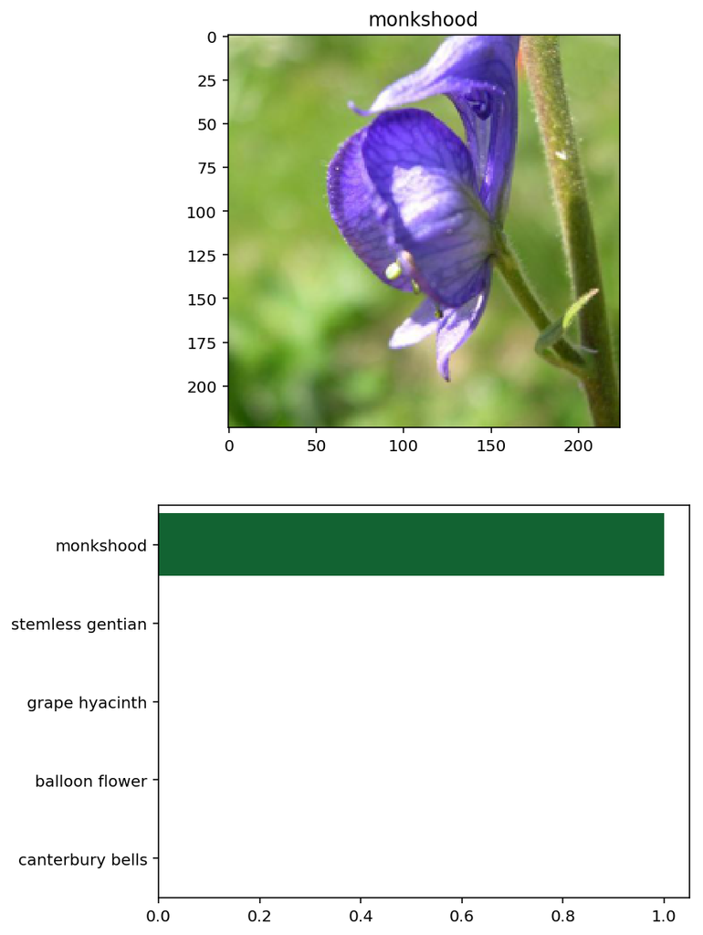

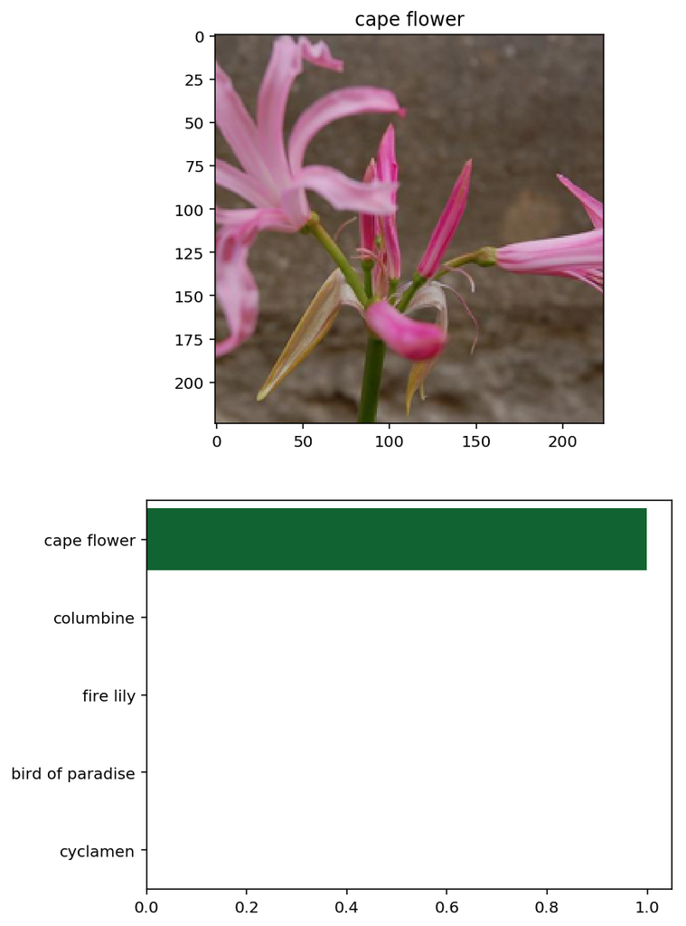

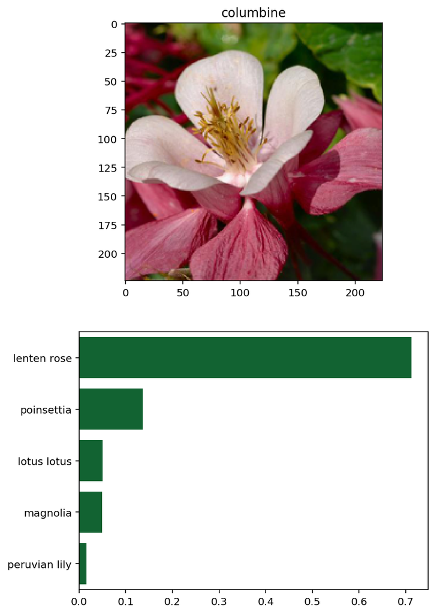

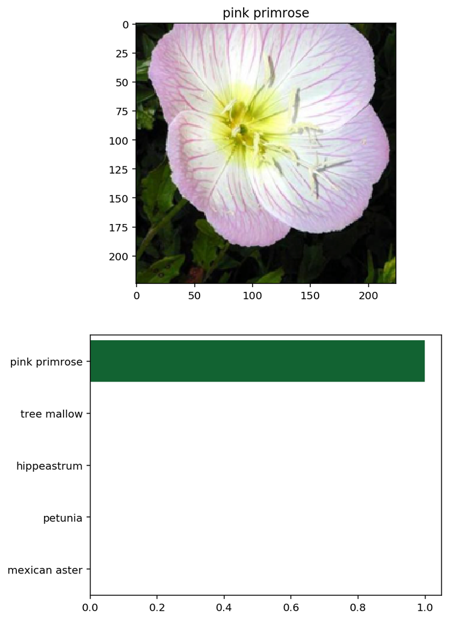

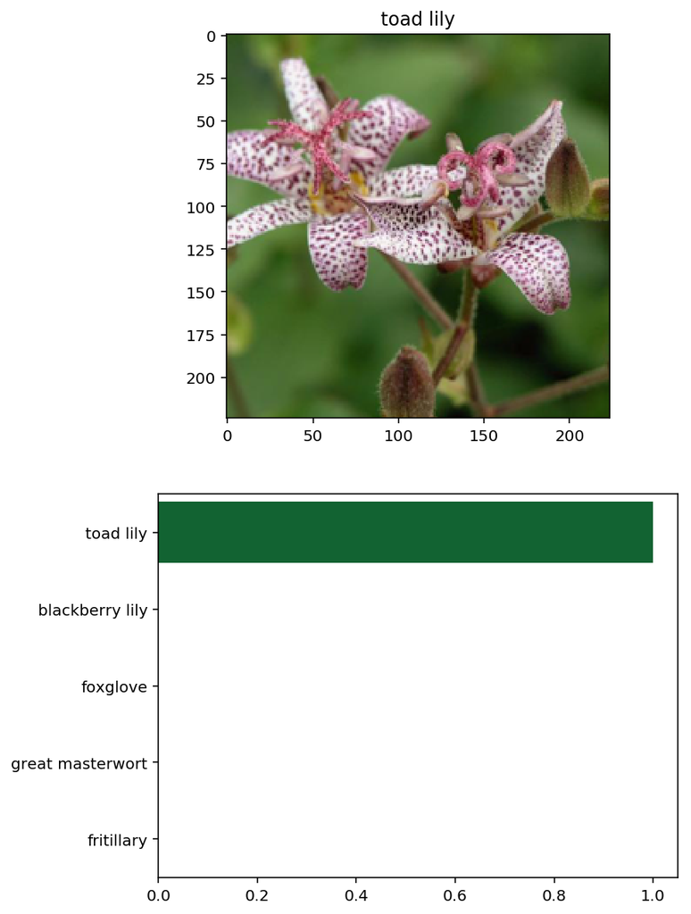

```python
test_file_paths = ['flowers/test/9/image_06410.jpg',
                   'flowers/test/37/image_03783.jpg',
                   'flowers/test/84/image_02615.jpg',
                   'flowers/test/1/image_06743.jpg',
                   'flowers/test/79/image_06720.jpg']

for i in range(len(test_file_paths)):
    plot(test_file_paths[i], model_loaded)
```